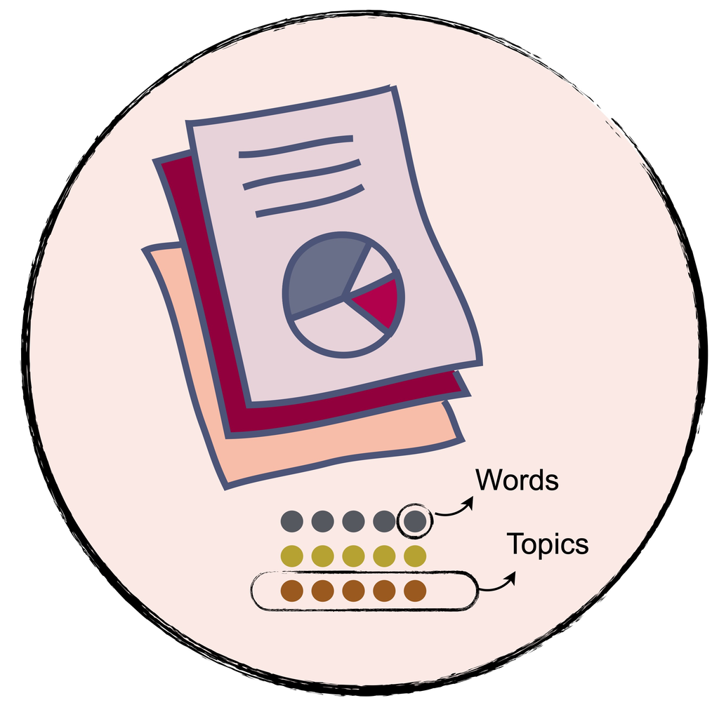

Topic Modeling (Unsupervised Information Extraction)

Topic modeling is a powerful Natural Language Processing (NLP) method for uncovering latent themes and subjects in large collections of text data. The technique identifies patterns and topics that frequently occur in the text and groups similar documents together, presenting the topics concisely using a limited number of key terms. Two of the most widely-used algorithms for topic modeling are Latent Dirichlet Allocation (LDA) and Non-Negative Matrix Factorization (NMF).

In the field of public health, topic modeling has several valuable applications. It can be used to process large amounts of unstructured information, such as electronic medical records, social media posts, or news articles, to gain deeper insights into public health trends and issues. For instance, it can be used to identify prevalent health concerns, track the progression of infectious diseases, or monitor public perceptions and attitudes toward health policies. This information can be leveraged to support informed decision-making and inform public health initiatives.

When to Use— Topic modeling is useful for extracting information from large text collections and classifying documents into various topics without prior knowledge of the categories. This approach can be particularly effective when working with big text data sets, as it helps to uncover underlying themes and topics in the data, whereas document classification requires labeled data for training. Additionally, topic modeling can be more suitable for text data that belongs to multiple categories, as it allows for a probabilistic model of the data, whereas document classification assumes a single category for each document. However, document classification may be the better choice in scenarios where predictions need to be made on new, unseen text data or when the categories are already known.

Example— For this example, we use a dataset gathered by [Gräßer, Felix et al.](https://kdd.cs.ksu.edu/Publications/Student/kallumadi2018aspect.pdf), consisting of patient feedback on specific drugs, the conditions they are related to, and a 10-star rating system indicating the patient’s overall satisfaction with the drug. The information was obtained by extracting it from online pharmaceutical review websites. The data has been used in a study on the sentiment analysis of drug experiences across various aspects, and it can be stored in different databases such as pharmacy management systems, financial systems, product category systems, and supply chain systems.

Implementation in R— The first step, as always, is to import the necessary libraries for implementing desired functionality and setting the theme for visualizations. The dataset is read from a public URL using the `read.csv()` function. If you need to read the file from your local machine, simply uncomment the `setwd()` function to set the working directory for your R session to the desired folder.

```r
library(tm)
library(dplyr)
library(SnowballC) #for text Stemmign
library(ggplot2)
library(tidytext)
library(wordcloud)
library(tidyr)
library(stringr)
library(textdata)
library(reshape2)
library(topicmodels)
library(purrr)

# #set the working directory to the directory that includes the dataset and the source code
# setwd(dirname(rstudioapi::getActiveDocumentContext()$path))

#read the data from URL
df <- read.csv("https://raw.githubusercontent.com/HIVE-UofT/Health-Data-Visualization/main/Lecture/drug_review.csv")
```

```r
#set the theme
theme_update(
  plot.background = element_rect(fill = "#FFFFFF", color = "#FFFFFF"),
  panel.background = element_rect(fill = "#FFFFFF", color = NA),
  axis.text.x = element_text(angle=0, face = "plain", color = "black", size = 10, hjust=1, vjust = 1, margin = margin(r = 0)),
  axis.text.y = element_text(face = "plain", color = "black", size = 11, hjust = 1, margin = margin(r = 5)),
  axis.line.x = element_line(color="black", size = .5),
  axis.line.y = element_line(color="black", size = .5),
  axis.ticks = element_blank(),
  axis.title.x = element_blank(),
  axis.title.y = element_blank(),
  plot.title = element_text(face = "bold", color = "black", size = 15, hjust = 0, margin = margin(b = 5, l=0)),
  plot.subtitle = element_text(face = "plain", color = "#737c7d", size = 10, hjust = 0, margin = margin(b = 20, l=10)),
  legend.text=element_text(face = "plain", color = "black", size = 12),
  legend.title = element_text(face = "bold", color = "black", size = 12)
)
```

Corpus in R

In R, a corpus is a collection of documents (or text data) stored in a format that is easy to process and analyze, such as a plain text file or a data frame. We use the `Corpus` function from the `tm` package to convert the `text` column of our dataset to a corpus using the following instruction:

```r
#create the Corpus
reviews <- Corpus(VectorSource(df$commentsReview))
# reviews
```

The `Corpus()` function cannot be used directly with character values, instead, the `VectorSource()` function from the `tm` package must be employed. This function converts a vector of text strings into a corpus object, which is then stored in the corpus collection. The `VectorSource()` function accepts a **vector of text strings** as an input and returns a **corpus object**.

Data Cleaning and Pre-processing

Text analysis heavily relies on data cleaning, which can be tedious but is crucial. Dirty data can produce inaccurate results. Data cleaning is not a one-time process, rather it is an iterative one that requires multiple rounds of implementation. Sometimes, you may need more than 100 iterations to thoroughly clean the data. The `tm` package provides various functions that facilitate the data cleaning process. To view the available options, enter `getTransformations()` in the **R** console. I general, the basic text cleaning/preparation steps are:

- Removing special characters and numbers
- Converting to lowercase or uppercase
- Removing white spaces
- Removing stop words
- Stemming or Lemmatization
- Removing punctuation
- Removing HTML tags
- Removing missing values
- Tokenization
- Correcting spelling mistakes.

```r
#create the toSpace content transformer
toSpace <- content_transformer(function(x, pattern) {return (gsub(pattern, " ", x))})
reviews <- tm_map(reviews, toSpace, "-")
reviews <- tm_map(reviews, toSpace, ":")
#Remove punctuation – replace punctuation marks with ” “
reviews <- tm_map(reviews, removePunctuation)

#Transform to lower case (need to wrap in content_transformer)
reviews <- tm_map(reviews,content_transformer(tolower))

#Strip digits
reviews <- tm_map(reviews, removeNumbers)

#remove stopwords using the standard list in tm
reviews <- tm_map(reviews, removeWords, stopwords("english"))

#Strip whitespace
reviews <- tm_map(reviews, stripWhitespace)

 #Stem document
reviews <- tm_map(reviews,stemDocument)

dtm <- DocumentTermMatrix(reviews)
dtm
```

```
## <<DocumentTermMatrix (documents: 4143, terms: 7573)>>
## Non-/sparse entries: 88239/31286700
## Sparsity           : 100%
## Maximal term length: 39
## Weighting          : term frequency (tf)
```

Before implementing the LDA algorithm, it is necessary to verify that the document-term matrix (dtm) does not contain any rows with all zeros, meaning every row must have at least one word with a frequency greater than zero. To do this, we use the apply() function in R to apply the `sum` function to the rows or columns of a matrix or dataframe. It takes the following arguments `apply(X, MARGIN, FUN)`:

- **X**: the matrix or data frame to apply the function to
- **MARGIN**: the dimension along which to apply the function (1 for rows, 2 for columns)
- **FUN**: the function to apply.

```r
# calculate the sum of the frequency words in each Document
dtm_rows_sum <- apply(dtm , 1, sum)
# filter the data to only keep documents with sum>0
dtm <- dtm[dtm_rows_sum> 0, ]
```

Now we are ready to start the topic modeling task. The `LDA()` function in R allows for implementing **Latent Dirichlet Allocation** on a text corpus represented in a document-term matrix format. This function, available in the `topicmodels` package, takes the document-term matrix and the number of desired topics as input and returns the estimated topic distributions and word-topic associations for each document in the corpus. In the following example, when the `LDA()` function is applied to a document-term matrix with three topics specified (k = 3), the output consists of the estimated topic probabilities for each document and the 10 words most closely associated with each topic. This information can then be visualized and analyzed to better understand the discovered topics.

```r
rw_lda <- LDA(dtm, k = 3, control = list(seed = 1234))
rw_lda
```

```
## A LDA_VEM topic model with 3 topics.
```

To extract the per-topic-per-word probabilities, we use **“beta”** from the `tidytext` package. The `tidy()` function from the `tidyr` package converts the output of the Latent Dirichlet Allocation (LDA) model (e.g., `rw_lda` in our example) into a tidy format. In the context of LDA, the `beta matrix` represents the word-topic associations and encodes the probability of each word in the vocabulary appearing in each topic. The `tidy()` function converts this matrix into a tidy format where each row represents a single word-topic association, with columns for the word, topic, and probability. This format makes it easier to manipulate, visualize, and analyze the word-topic associations.

```r
rw_topics <- tidy(rw_lda, matrix = "beta")
rw_topics
```

```
## # A tibble: 22,719 × 3
##    topic term         beta
##    <int> <chr>       <dbl>
##  1     1 antibiot 0.000908
##  2     2 antibiot 0.00142
##  3     3 antibiot 0.000782
##  4     1 day      0.0258
##  5     2 day      0.0234
##  6     3 day      0.0149
##  7     1 gone     0.000437
##  8     2 gone     0.000674
##  9     3 gone     0.000762
## 10     1 infect   0.000988
## # … with 22,709 more rows
```

To find the 10 terms that are most common within each topic, we can use dplyr’s `top_n()` function.

> `%>%` is the pipe operator in R. It allows the output of one function to be passed as the input to another function, allowing for more readable and compact code. The pipe operator essentially takes the output from one function and “pipes” it directly into the input of the following function, allowing the output from one function to be used as the input to another function without the need for intermediate variables or steps.This greatly reduces the amount of code required to achieve the same result and makes it easier to understand a script’s overall flow and logic.
- We use the `arrange()` function to sort the rows of a dataframe based on one or more columns (in this example **beta**).
- The `mutate` function from the `dplyr` package in R allows you to **create new columns** in a dataframe by calculating the values in existing columns. The function takes a dataframe as its input and returns a new dataframe with the added columns. This capability of the `mutate` function makes it a useful tool for data analysis and modeling, as it enables the creation of new variables or columns derived from existing data. In the following example, we replace the existing **term** column with a *sorted* column.
- The `facet_wrap()` function in the R package `ggplot2` creates faceted plots by dividing a ggplot into smaller subplots organized in a **2D layout**. This is achieved by wrapping the faceting variables based on the values of one or more categorical variables. As a result, it is possible to display the same plot type for different data subsets neatly and compactly. We can define the number of columns or rows of the sub-fugres by using the `ncol` or `nrow` arguments in the `facet_wrap()` function.
- When the `x-axis` is crowded, or the `y-axis` is too long in a plot, `coord_flip()`, a function in the `ggplot2` package in R, can be useful. It flips the **x** and **y-axis** coordinates, effectively swapping the horizontal and vertical dimensions of the plot, allowing for a better representation of the data.
- `scale_x_reordered()` is a function in `ggplot2` in R that changes the order of the x-axis levels in a plot. It helps to reorder the levels based on frequency or custom order to improve the plot’s effectiveness.

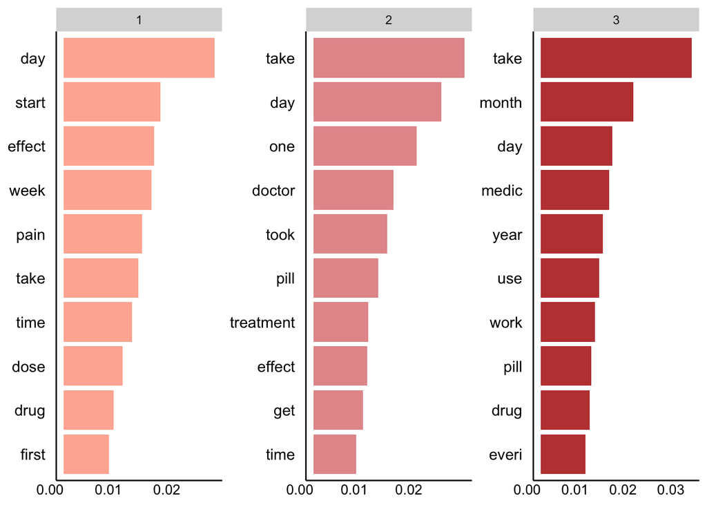

```r
rw_top_terms <- rw_topics %>%
  group_by(topic) %>%
  top_n(10, beta) %>%
  ungroup() %>%
  arrange(topic, -beta)

#Make the bar plot
rw_top_terms %>%
  mutate(term = reorder_within(term, beta, topic)) %>%
  ggplot(aes(term, beta, fill = factor(topic))) +
  scale_fill_manual(values = c("#ffb4a2", "#e5989b", "#bf4342")) +
  geom_col(show.legend = FALSE) +
  facet_wrap(~ topic, scales = "free") +
  coord_flip() +
  scale_x_reordered()
```

We need to try different values of *k* (# of topics) and make a choice based by inspecting the results. Let’s try `k=4`. We use dplyr’s `top_n()` to find the top 5 terms within each topic.

```r
reviews_lda <- LDA(dtm, k = 4, control = list(seed = 1234))
reviews_topics <- tidy(reviews_lda, matrix = "beta")

top_terms <- reviews_topics %>%
  group_by(topic) %>%
  top_n(5, beta) %>%
  ungroup() %>%
  arrange(topic, -beta)
```

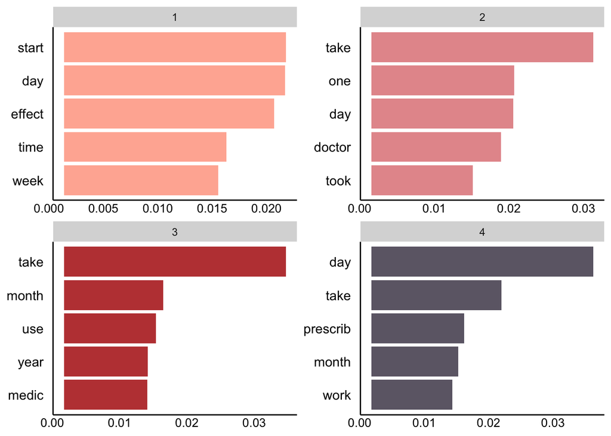

```r
# visualize the results
top_terms %>%
  mutate(term = reorder_within(term, beta, topic)) %>%
  ggplot(aes(term, beta, fill = factor(topic))) +
  scale_fill_manual(values = c("#ffb4a2", "#e5989b", "#bf4342", "#6d6875")) +
  geom_col(show.legend = FALSE) +
  facet_wrap(~ topic, scales = "free") +
  coord_flip() +
  scale_x_reordered()
```

The Latent Dirichlet Allocation (LDA) algorithm produces a result that holds extensive data. Out of all the information, the document-to-topic assignments, the most significant terms in each topic, and the likelihoods linked with each term are particularly relevant to us. Therefore, it is crucial to analyze the output and identify the topics that can be inferred based on the top terms related to them. Furthermore, understanding the output of the LDA algorithm can provide valuable insights into the patterns and relationships in the data being analyzed.

How Many Topics?

To determine the optimal number of topics that accurately represent our dataset, we utilize the perplexity metric. The perplexity metric is a valuable tool that assesses the fit of a probabilistic model to a given sample. By calculating the perplexity for different numbers of topics, we can identify the number that results in the lowest perplexity and is therefore the best representation of our data.In the following code snippet:

- The `map_dbl()` function is a part of the `purrr` library and it applies a function (**perplexity** in our example) to each element of a list and returns the result as a numeric vector.
- We use the `data.frame()` function to convert the calculation results to a dataframe.

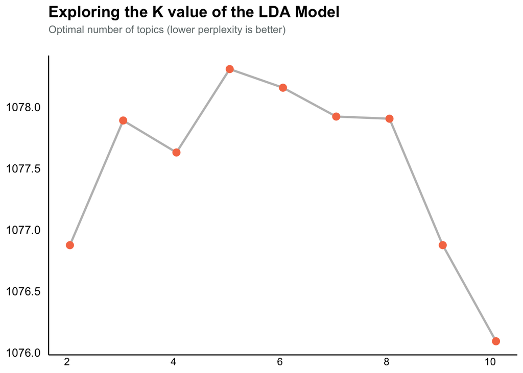

```r
k_val <- c(2,3,4,5,6,7,8,9,10)
rw_lda_compare <- k_val %>%
  purrr::map(LDA, x = dtm, control = list(seed = 1109))

data_frame(k = k_val,
           perplex = map_dbl(rw_lda_compare, perplexity)) %>%
  ggplot(aes(k, perplex)) +
  geom_line(color = "grey", size=1) +
  geom_point(color = "#F67A53", size =3) +
  labs(title = "Exploring the K value of the LDA Model",
       subtitle = "Optimal number of topics (lower perplexity is better)",
       x = "# of topics",
       y = "Perplexity")
```